# Accessing the EDGAR 10-K Dataset

- Show All Code
- Hide All Code
- View Source

Research in Corporate Transparency 2026

Author

Fikir Worku Edossa

## 1 Overview

The EDGAR 10-K dataset is available as parquet files on the TRR266 server. The files can be queried directly over HTTPS with DuckDB, so it is not necessary to download the full dataset before starting an analysis.

The dataset contains both filing metadata with downloaded filing documents. Two columns that contain the actual filing text:

- `filing_raw_html`: the raw SEC HTML document.
- `filing_markdown`: a Markdown/plain-text-oriented conversion of the filing.

The full text columns are large. Downloading the text columns for the entire dataset can require around 30 gigabytes of storage. Start with metadata-only queries, then pull text only for the sample needed for a specific research question.

## 2 Setup

The dataset is hosted on the TRR266 server and exposed as a plain HTTPS directory of parquet files — no API, no wildcard expansion. Four steps are needed before queries can run:

1. Import the packages.
2. Scrape the server directory to collect the individual parquet file URLs.
3. Format the URL list into a SQL literal that DuckDB’s `parquet_scan()` accepts.
4. Install the `httpfs` extension, then create a view called `edgar_10k` over the remote files.

The view is a SQL alias, not a local copy of the data. Creating it does not download any filing text — DuckDB pulls only the rows and columns a query actually requests. All of the following queries use `edgar_10k` as their table.

### 2.1 Import Packages

We use DuckDB as the query engine. DuckDB can query parquet files directly and, with the `httpfs` extension, can read remote files over HTTPS. The other packages are used for listing files from the server page, displaying text, and plotting.

```python
import time
from html import escape
from pathlib import Path
from urllib.parse import urljoin

import duckdb
import matplotlib.pyplot as plt
import pandas as pd
import requests
from bs4 import BeautifulSoup
from IPython.display import HTML, display


def print_elapsed(start_time: float, label: str) -> None:
    elapsed = time.perf_counter() - start_time
    print(f"[{label}: {elapsed:.2f} s]")
```

The base URL points to the TRR266 server directory where the parquet files live. The text column set is used throughout to exclude the large filing columns from metadata-only queries. The sample constants keep the local text sample reproducible and easy to resize.

```python
BASE_URL = "https://trr266.wiwi.hu-berlin.de/edgar_10k_apr26/"
TEXT_COLUMNS = {"filing_raw_html", "filing_markdown"}
SAMPLE_SEED = "my-project-seed"
N_TEXT_SAMPLE = 100
```

### 2.2 Collect Remote Parquet Files

The TRR266 server exposes the parquet files through a regular HTTPS directory listing. DuckDB can read the individual files, but it does not expand `*.parquet` automatically for this kind of generic HTTP directory. The helper below reads the directory page and extracts the parquet links.

```python
def list_parquet_files(base_url: str) -> list[str]:
    response = requests.get(base_url, timeout=30)
    response.raise_for_status()
    soup = BeautifulSoup(response.text, "html.parser")
    files = []
    for anchor in soup.find_all("a"):
        href = anchor.get("href")
        if href and href.lower().endswith(".parquet"):
            files.append(urljoin(base_url, href))
    return sorted(files)
```

Now collect the parquet file URLs.

```python
start = time.perf_counter()
parquet_urls = list_parquet_files(BASE_URL)
print_elapsed(start, "list parquet files")

pd.DataFrame({"n_parquet_files": [len(parquet_urls)]})
```

```
[list parquet files: 0.12 s]
```

|  | n_parquet_files |
| --- | --- |
| 0 | 1786 |

### 2.3 Format The File List For DuckDB

`parquet_scan()` can receive a list of files. The next helper turns the Python list of URLs into a SQL list literal that can be inserted into the DuckDB query.

```python
def duckdb_list_literal(urls: list[str]) -> str:
    escaped = [url.replace("'", "''") for url in urls]
    return "['" + "','".join(escaped) + "']"


file_list = duckdb_list_literal(parquet_urls)
```

### 2.4 Set Up DuckDB

`httpfs` is the DuckDB extension that allows remote file access over HTTPS. The metadata cache reduces repeated HTTP metadata requests during the session.

```python
con = duckdb.connect()
con.execute("INSTALL httpfs;")
con.execute("LOAD httpfs;")
con.execute("SET enable_http_metadata_cache = true;")
```

```
<_duckdb.DuckDBPyConnection at 0x76bec98dbb30>
```

### 2.5 Create The EDGAR View

The main object used below is the `edgar_10k` view. The `SELECT` statement also performs a few light type conversions so that mixed source columns such as `sic`, `filmNumber`, and `items` are easier to work with.

```python
con.execute(f"""
    CREATE OR REPLACE VIEW edgar_10k AS
    SELECT
        cik,
        name,
        tickers,
        exchanges,
        entityType,
        TRY_CAST(sic AS BIGINT) AS sic,
        sicDescription,
        stateOfIncorporation,
        TRY_CAST(fiscalYearEnd AS BIGINT) AS fiscalYearEnd,
        form,
        filingDate,
        reportDate,
        acceptanceDateTime,
        accessionNumber,
        fileNumber,
        CAST(filmNumber AS VARCHAR) AS filmNumber,
        TRY_CAST(filmNumber AS DOUBLE) AS filmNumber_num,
        CAST(items AS VARCHAR) AS items,
        TRY_CAST(items AS DOUBLE) AS items_num,
        size,
        isXBRL,
        isInlineXBRL,
        primaryDocument,
        primaryDocDescription,
        primaryDocUrl,
        filing_raw_html,
        filing_markdown,
        TRY_CAST(filing_word_count AS BIGINT) AS filing_word_count,
        download_success,
        download_error,
        filename
    FROM parquet_scan(
        {file_list},
        filename = true,
        union_by_name = true
    )
""")
```

```
<_duckdb.DuckDBPyConnection at 0x76bec98dbb30>
```

After this point, queries can refer to `edgar_10k` as if it were a table. DuckDB still keeps the work lazy: selecting metadata columns does not require downloading the full filing text columns.

The first thing to inspect is the schema. This confirms which columns are available before selecting rows.

```python
schema = con.execute("DESCRIBE edgar_10k").fetchdf()
schema
```

|  | column_name | column_type | null | key | default | extra |
| --- | --- | --- | --- | --- | --- | --- |
| 0 | cik | BIGINT | YES | None | None | None |
| 1 | name | VARCHAR | YES | None | None | None |
| 2 | tickers | VARCHAR | YES | None | None | None |
| 3 | exchanges | VARCHAR | YES | None | None | None |
| 4 | entityType | VARCHAR | YES | None | None | None |
| 5 | sic | BIGINT | YES | None | None | None |
| 6 | sicDescription | VARCHAR | YES | None | None | None |
| 7 | stateOfIncorporation | VARCHAR | YES | None | None | None |
| 8 | fiscalYearEnd | BIGINT | YES | None | None | None |
| 9 | form | VARCHAR | YES | None | None | None |
| 10 | filingDate | VARCHAR | YES | None | None | None |
| 11 | reportDate | VARCHAR | YES | None | None | None |
| 12 | acceptanceDateTime | VARCHAR | YES | None | None | None |
| 13 | accessionNumber | VARCHAR | YES | None | None | None |
| 14 | fileNumber | VARCHAR | YES | None | None | None |
| 15 | filmNumber | VARCHAR | YES | None | None | None |
| 16 | filmNumber_num | DOUBLE | YES | None | None | None |
| 17 | items | VARCHAR | YES | None | None | None |
| 18 | items_num | DOUBLE | YES | None | None | None |
| 19 | size | BIGINT | YES | None | None | None |
| 20 | isXBRL | BIGINT | YES | None | None | None |
| 21 | isInlineXBRL | BIGINT | YES | None | None | None |
| 22 | primaryDocument | VARCHAR | YES | None | None | None |
| 23 | primaryDocDescription | VARCHAR | YES | None | None | None |
| 24 | primaryDocUrl | VARCHAR | YES | None | None | None |
| 25 | filing_raw_html | VARCHAR | YES | None | None | None |
| 26 | filing_markdown | VARCHAR | YES | None | None | None |
| 27 | filing_word_count | BIGINT | YES | None | None | None |
| 28 | download_success | BOOLEAN | YES | None | None | None |
| 29 | download_error | VARCHAR | YES | None | None | None |
| 30 | filename | VARCHAR | YES | None | None | None |

The preview blocks below use this small helper to display long filing text with wrapping.

```python
def block(text: str) -> HTML:
    return HTML(f'<div class="text-preview-block">{escape(text)}</div>')
```

## 3 Dataset Overview

```python
start = time.perf_counter()
metadata_overview = con.execute("""
    SELECT
        COUNT(*) AS n_rows,
        COUNT(DISTINCT filename) AS n_remote_parquet_files,
        COUNT(DISTINCT cik) AS n_unique_cik,
        COUNT(DISTINCT accessionNumber) AS n_unique_accessions,
        SUM(CASE WHEN download_success THEN 1 ELSE 0 END) AS n_download_success,
        MIN(filingDate) AS first_filing_date,
        MAX(filingDate) AS last_filing_date
    FROM edgar_10k
""").fetchdf()
print_elapsed(start, "dataset overview")

metadata_overview
```

```
[dataset overview: 2.41 s]
```

|  | n_rows | n_remote_parquet_files | n_unique_cik | n_unique_accessions | n_download_success | first_filing_date | last_filing_date |
| --- | --- | --- | --- | --- | --- | --- | --- |
| 0 | 178519 | 1786 | 33955 | 172109 | 175899.0 | 1999-06-28 | 2026-04-10 |

## 4 Access Pattern

The practical pattern is to query all columns except the large text columns first. This keeps the first-pass data work fast and manageable.

```python
text_columns = {"filing_raw_html", "filing_markdown"}
columns = schema["column_name"].tolist()
metadata_columns = [col for col in columns if col not in text_columns]
metadata_select = ", ".join(f'"{col}"' for col in metadata_columns)

start = time.perf_counter()
metadata_preview = con.execute(f"""
    SELECT {metadata_select}
    FROM edgar_10k
    WHERE filingDate IS NOT NULL
    ORDER BY filingDate DESC, cik
    LIMIT 10
""").fetchdf()
print_elapsed(start, "metadata preview")

metadata_preview
```

```
[metadata preview: 0.17 s]
```

|  | cik | name | tickers | exchanges | entityType | sic | sicDescription | stateOfIncorporation | fiscalYearEnd | form | ... | size | isXBRL | isInlineXBRL | primaryDocument | primaryDocDescription | primaryDocUrl | filing_word_count | download_success | download_error | filename |
| --- | --- | --- | --- | --- | --- | --- | --- | --- | --- | --- | --- | --- | --- | --- | --- | --- | --- | --- | --- | --- | --- |
| 0 | 1041859 | Childrens Place, Inc. | PLCE | Nasdaq | operating | 5651 | Retail-Family Clothing Stores | None | 131 | 10-K | ... | 10809274 | 1 | 1 | plce-20260131.htm | 10-K | https://www.sec.gov/Archives/edgar/data/104185... | 58781 | True | None | https://trr266.wiwi.hu-berlin.de/edgar_10k_apr... |
| 1 | 1058623 | CUMULUS MEDIA INC | CMLS\|CMLSQ | OTC\|OTC | operating | 4832 | Radio Broadcasting Stations | DE | 1231 | 10-K | ... | 11358386 | 1 | 1 | cmls-20251231.htm | 10-K | https://www.sec.gov/Archives/edgar/data/105862... | 63324 | True | None | https://trr266.wiwi.hu-berlin.de/edgar_10k_apr... |
| 2 | 1080448 | PATRIOT GOLD CORP | PGOL | OTC | operating | 1040 | Gold and Silver Ores | NV | 1231 | 10-K | ... | 4668220 | 1 | 1 | patriot_i10k-123125.htm | FORM 10-K FOR DEC 2025 | https://www.sec.gov/Archives/edgar/data/108044... | 27450 | True | None | https://trr266.wiwi.hu-berlin.de/edgar_10k_apr... |
| 3 | 1098009 | America Great Health | None | None | operating | 2834 | Pharmaceutical Preparations | CA | 630 | 10-K | ... | 6100689 | 1 | 1 | aagh10k063025.htm | FORM 10-K | https://www.sec.gov/Archives/edgar/data/109800... | 20371 | True | None | https://trr266.wiwi.hu-berlin.de/edgar_10k_apr... |
| 4 | 1134982 | Apple iSports Group, Inc. | AAPI | OTC | operating | 6411 | Insurance Agents, Brokers & Service | NV | 1231 | 10-K | ... | 4079915 | 1 | 1 | aapi_10k.htm | FORM 10-K | https://www.sec.gov/Archives/edgar/data/113498... | 33772 | True | None | https://trr266.wiwi.hu-berlin.de/edgar_10k_apr... |
| 5 | 1166708 | Brownie's Marine Group, Inc | BWMG | OTC | operating | 3949 | Sporting & Athletic Goods, NEC | FL | 1231 | 10-K | ... | 10221357 | 1 | 1 | form10-k.htm | 10-K | https://www.sec.gov/Archives/edgar/data/116670... | 37457 | True | None | https://trr266.wiwi.hu-berlin.de/edgar_10k_apr... |
| 6 | 1425627 | SOBR Safe, Inc. | SOBR | Nasdaq | operating | 2721 | Periodicals: Publishing or Publishing & Printing | DE | 1231 | 10-K | ... | 6758395 | 1 | 1 | sobr_10k.htm | FORM 10-K | https://www.sec.gov/Archives/edgar/data/142562... | 46363 | True | None | https://trr266.wiwi.hu-berlin.de/edgar_10k_apr... |
| 7 | 1494413 | Two Hands Corp | TWOH | OTC | operating | 7389 | Services-Business Services, NEC | None | 1231 | 10-K | ... | 5206486 | 1 | 1 | twoh12312025k.htm | FORM 10-K | https://www.sec.gov/Archives/edgar/data/149441... | 28216 | True | None | https://trr266.wiwi.hu-berlin.de/edgar_10k_apr... |
| 8 | 1632121 | Balance Labs, Inc. | BLNC | OTC | operating | 8742 | Services-Management Consulting Services | DE | 1231 | 10-K | ... | 6448486 | 1 | 1 | form10-k.htm | 10-K | https://www.sec.gov/Archives/edgar/data/163212... | 24363 | True | None | https://trr266.wiwi.hu-berlin.de/edgar_10k_apr... |
| 9 | 1662774 | Quince Therapeutics, Inc. | QNCX | Nasdaq | operating | 2836 | Biological Products, (No Diagnostic Substances) | CA | 1231 | 10-K | ... | 16792188 | 1 | 1 | qncx-20251231.htm | 10-K | https://www.sec.gov/Archives/edgar/data/166277... | 59811 | True | None | https://trr266.wiwi.hu-berlin.de/edgar_10k_apr... |

10 rows × 29 columns

## 5 Codebook

|  | column_name | column_type | text_heavy | description |
| --- | --- | --- | --- | --- |
| 0 | cik | BIGINT | False | SEC Central Index Key. Identifies the registra... |
| 1 | name | VARCHAR | False | Registrant name from SEC company metadata. |
| 2 | tickers | VARCHAR | False | Ticker symbols reported in SEC company metadat... |
| 3 | exchanges | VARCHAR | False | Exchanges associated with the ticker symbols, ... |
| 4 | entityType | VARCHAR | False | SEC entity type, often operating for ordinary ... |
| 5 | sic | BIGINT | False | Standard Industrial Classification code, cast ... |
| 6 | sicDescription | VARCHAR | False | Text label for the SIC industry. |
| 7 | stateOfIncorporation | VARCHAR | False | State or jurisdiction of incorporation. |
| 8 | fiscalYearEnd | BIGINT | False | Fiscal year-end as MMDD, cast to numeric when ... |
| 9 | form | VARCHAR | False | SEC form type. |
| 10 | filingDate | VARCHAR | False | Date on which the filing was filed with the SEC. |
| 11 | reportDate | VARCHAR | False | Fiscal period-end date covered by the filing. |
| 12 | acceptanceDateTime | VARCHAR | False | SEC acceptance timestamp for the filing. |
| 13 | accessionNumber | VARCHAR | False | Unique SEC accession number for the filing sub... |
| 14 | fileNumber | VARCHAR | False | SEC file number associated with the registrant... |
| 15 | filmNumber | VARCHAR | False | SEC film number as text. Kept as text because ... |
| 16 | filmNumber_num | DOUBLE | False | Numeric version of filmNumber when conversion ... |
| 17 | items | VARCHAR | False | Filing item metadata from the SEC source, kept... |
| 18 | items_num | DOUBLE | False | Numeric version of items when conversion succe... |
| 19 | size | BIGINT | False | Size of the primary filing document in bytes, ... |
| 20 | isXBRL | BIGINT | False | Indicator for whether the filing has XBRL cont... |
| 21 | isInlineXBRL | BIGINT | False | Indicator for whether the filing has inline XB... |
| 22 | primaryDocument | VARCHAR | False | Primary document filename, for example d10k.htm. |
| 23 | primaryDocDescription | VARCHAR | False | SEC description of the primary document. |
| 24 | primaryDocUrl | VARCHAR | False | Direct URL to the primary document on sec.gov. |
| 25 | filing_raw_html | VARCHAR | True | Raw SEC filing HTML. Useful when original docu... |
| 26 | filing_markdown | VARCHAR | True | Converted Markdown text. Usually the best star... |
| 27 | filing_word_count | BIGINT | False | Approximate word count of the converted filing... |
| 28 | download_success | BOOLEAN | False | Whether the filing document was successfully d... |
| 29 | download_error | VARCHAR | False | Error message if the filing download/conversio... |
| 30 | filename | VARCHAR | False | Remote parquet part from which the row was read. |

Rows marked `text_heavy = True` are the columns to avoid in first-pass full-dataset queries.

## 6 Industry Coverage

```python
start = time.perf_counter()
top_sic = con.execute("""
    SELECT sic, sicDescription, COUNT(*) AS n
    FROM edgar_10k
    WHERE sicDescription IS NOT NULL
    GROUP BY sic, sicDescription
    ORDER BY n DESC
    LIMIT 10
""").fetchdf()
print_elapsed(start, "industry coverage")

top_sic
```

```
[industry coverage: 0.10 s]
```

|  | sic | sicDescription | n |
| --- | --- | --- | --- |
| 0 | 6189 | Asset-Backed Securities | 21930 |
| 1 | 2834 | Pharmaceutical Preparations | 9214 |
| 2 | 6798 | Real Estate Investment Trusts | 6320 |
| 3 | 7372 | Services-Prepackaged Software | 5479 |
| 4 | 6022 | State Commercial Banks | 5358 |
| 5 | 1311 | Crude Petroleum & Natural Gas | 4474 |
| 6 | 6770 | Blank Checks | 3656 |
| 7 | 7389 | Services-Business Services, NEC | 3502 |
| 8 | 6021 | National Commercial Banks | 2854 |
| 9 | 3841 | Surgical & Medical Instruments & Apparatus | 2763 |

## 7 Example: Filing Length Over Time

`filing_word_count` is a transparent first variable for studying disclosure length or complexity.

```
[filings by year: 0.12 s]
```

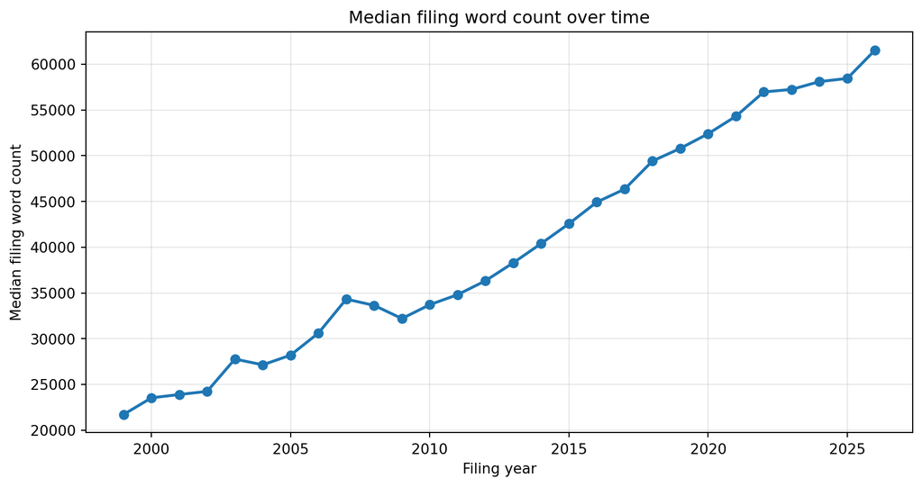

```python
start = time.perf_counter()
filings_by_year = con.execute("""
    SELECT
        SUBSTR(filingDate, 1, 4) AS filing_year,
        COUNT(*) AS n_filings,
        COUNT(DISTINCT cik) AS n_unique_cik,
        CAST(ROUND(MEDIAN(filing_word_count)) AS BIGINT) AS median_words,
        CAST(ROUND(AVG(filing_word_count)) AS BIGINT) AS mean_words
    FROM edgar_10k
    WHERE filingDate IS NOT NULL
      AND filing_word_count IS NOT NULL
    GROUP BY filing_year
    ORDER BY filing_year
""").fetchdf()
print_elapsed(start, "filings by year")

plot_df = filings_by_year.copy()
plot_df["filing_year"] = plot_df["filing_year"].astype(int)

fig, ax = plt.subplots(figsize=(9, 4.8))
ax.plot(plot_df["filing_year"], plot_df["median_words"], marker="o", linewidth=2)
ax.set_xlabel("Filing year")
ax.set_ylabel("Median filing word count")
ax.set_title("Median filing word count over time")
ax.grid(True, alpha=0.3)
plt.tight_layout()
plt.show()
```

## 8 Annual Summary

```python
filings_by_year
```

|  | filing_year | n_filings | n_unique_cik | median_words | mean_words |
| --- | --- | --- | --- | --- | --- |
| 0 | 1999 | 16 | 16 | 21713 | 22200 |
| 1 | 2000 | 519 | 516 | 23534 | 24526 |
| 2 | 2001 | 3132 | 3095 | 23897 | 24597 |
| 3 | 2002 | 5267 | 5133 | 24238 | 24606 |
| 4 | 2003 | 6445 | 6367 | 27774 | 28623 |
| 5 | 2004 | 6596 | 6506 | 27141 | 27881 |
| 6 | 2005 | 7080 | 7015 | 28203 | 28777 |
| 7 | 2006 | 6940 | 6880 | 30613 | 30927 |
| 8 | 2007 | 6687 | 6557 | 34324 | 36146 |
| 9 | 2008 | 6917 | 6779 | 33641 | 34243 |
| 10 | 2009 | 8125 | 7956 | 32200 | 35916 |
| 11 | 2010 | 7607 | 7406 | 33716 | 37952 |
| 12 | 2011 | 7411 | 7209 | 34812 | 39193 |
| 13 | 2012 | 7086 | 6964 | 36329 | 40462 |
| 14 | 2013 | 6938 | 6790 | 38295 | 42049 |
| 15 | 2014 | 7095 | 6940 | 40397 | 43234 |
| 16 | 2015 | 7161 | 7021 | 42571 | 45013 |
| 17 | 2016 | 6945 | 6778 | 44930 | 46704 |
| 18 | 2017 | 6773 | 6639 | 46348 | 48539 |
| 19 | 2018 | 6766 | 6620 | 49419 | 50779 |
| 20 | 2019 | 6673 | 6573 | 50803 | 51491 |
| 21 | 2020 | 6610 | 6500 | 52402 | 52617 |
| 22 | 2021 | 7083 | 6923 | 54317 | 54870 |
| 23 | 2022 | 7704 | 7613 | 56974 | 56278 |
| 24 | 2023 | 7308 | 7220 | 57247 | 56908 |
| 25 | 2024 | 6840 | 6755 | 58104 | 58116 |
| 26 | 2025 | 6681 | 6549 | 58451 | 58546 |
| 27 | 2026 | 5494 | 5394 | 61561 | 60977 |

## 9 Saving A Text Sample Locally

For text analysis, save a sample rather than the full corpus. The full text columns can reach tens of gigabytes across the whole dataset. The workflow below first stores the selected observation identifiers, `cik` and `accessionNumber`, in a temporary table. It also keeps `filename` internally so DuckDB can fetch text from only the parquet files that contain the selected observations.

```python
text_sample_path = Path("edgar_10k_markdown_sample.parquet")
text_sample_path.unlink(missing_ok=True)

start = time.perf_counter()
con.execute(f"""
    CREATE OR REPLACE TEMP TABLE text_sample_ids AS
    SELECT cik, accessionNumber, filename
    FROM (
        SELECT DISTINCT cik, accessionNumber, filename
        FROM edgar_10k
        WHERE download_success = true
          AND filing_word_count IS NOT NULL
          AND cik IS NOT NULL
          AND accessionNumber IS NOT NULL
          AND filename IS NOT NULL
    ) AS eligible_filings
    ORDER BY hash(CAST(cik AS VARCHAR) || accessionNumber || '{SAMPLE_SEED}')
    LIMIT {N_TEXT_SAMPLE}
""")

selected_text_files = con.execute("""
    SELECT DISTINCT filename
    FROM text_sample_ids
    ORDER BY filename
""").fetchdf()["filename"].tolist()
selected_text_file_list = duckdb_list_literal(selected_text_files)

con.execute(f"""
    COPY (
        SELECT
            TRY_CAST(e.cik AS BIGINT) AS cik,
            e.name,
            e.sicDescription,
            e.form,
            e.filingDate,
            e.reportDate,
            e.accessionNumber,
            e.primaryDocUrl,
            TRY_CAST(e.filing_word_count AS BIGINT) AS filing_word_count,
            e.filing_markdown,
            e.filing_raw_html
        FROM parquet_scan(
            {selected_text_file_list},
            filename = true,
            union_by_name = true
        ) AS e
        INNER JOIN text_sample_ids AS s
            ON TRY_CAST(e.cik AS BIGINT) = s.cik
           AND e.accessionNumber = s.accessionNumber
           AND e.filename = s.filename
        ORDER BY hash(CAST(TRY_CAST(e.cik AS BIGINT) AS VARCHAR) || e.accessionNumber || '{SAMPLE_SEED}')
    )
    TO '{text_sample_path.as_posix()}'
    (FORMAT PARQUET)
""")
print_elapsed(start, "save text sample")
```

```
[save text sample: 63.35 s]
```

After saving, check the size and shape.

```python
start = time.perf_counter()
text_sample_shape = con.execute(f"""
    SELECT
        COUNT(*) AS n_observations,
        COUNT(*) FILTER (WHERE filing_markdown IS NOT NULL) AS n_with_markdown,
        COUNT(*) FILTER (WHERE filing_raw_html IS NOT NULL) AS n_with_html
    FROM read_parquet('{text_sample_path.as_posix()}')
""").fetchdf()
print_elapsed(start, "text sample summary")

text_sample_columns = con.execute(
    f"DESCRIBE SELECT * FROM read_parquet('{text_sample_path.as_posix()}')"
).fetchdf()

text_sample_summary = text_sample_shape.assign(
    n_columns=len(text_sample_columns),
    file_size_mb=round(text_sample_path.stat().st_size / 1024**2, 2),
)

text_sample_summary
```

```
[text sample summary: 0.13 s]
```

|  | n_observations | n_with_markdown | n_with_html | n_columns | file_size_mb |
| --- | --- | --- | --- | --- | --- |
| 0 | 100 | 100 | 100 | 11 | 42.76 |

## 10 Inspecting Filing Text

One filing from the saved sample is displayed below. Both text columns were saved locally, so no additional remote fetching is needed.

```python
start = time.perf_counter()
text_preview = con.execute(f"""
    SELECT
        cik,
        name,
        form,
        filingDate,
        sicDescription,
        filing_word_count,
        primaryDocUrl,
        filing_markdown AS markdown_preview,
        filing_raw_html AS html_preview
    FROM read_parquet('{text_sample_path.as_posix()}')
    WHERE filing_markdown IS NOT NULL
      AND filing_raw_html IS NOT NULL
    ORDER BY hash(COALESCE(accessionNumber, '') || 'rct2026-preview')
    LIMIT 1
""").fetchdf()
print_elapsed(start, "text preview")

text_preview[["cik", "name", "form", "filingDate", "sicDescription", "filing_word_count", "primaryDocUrl"]]
```

```
[text preview: 0.14 s]
```

|  | cik | name | form | filingDate | sicDescription | filing_word_count | primaryDocUrl |
| --- | --- | --- | --- | --- | --- | --- | --- |
| 0 | 1270430 | PDC 2003-D LP | 10-K | 2005-04-25 | Drilling Oil & Gas Wells | 9949 | https://www.sec.gov/Archives/edgar/data/127043... |

## 11 Markdown Preview

```python
display(block(text_preview.loc[0, "markdown_preview"]))
```

10-K 1 pdc10k03d041.htm CONFORMED COPY CONFORMED COPY SECURITIES AND EXCHANGE COMMISSION Washington, D.C. 20549 Form 10-K [X] ANNUAL REPORT PURSUANT TO SECTION 13 or 15 (d) OF THE SECURITIES EXCHANGE ACT OF 1934 For the fiscal year ended December 31, 2004 Commission File Number 000-50618 []Transition Report Pursuant to Section 13 or 15(d) of the Securities Exchange Act of 1934 for the transaction period from to PDC 2003-D LIMITED PARTNERSHIP (Exact name of registrant as specified in its charter) | West Virginia<br>(State or other jurisdiction of<br>incorporation or organization) | 56-2348528<br>(I.R.S. Employer<br>Identification No.) | | --- | --- | 103 East Main Street, Bridgeport, West Virginia 26330 (Address of principal executive offices) (zip code) Registrant's telephone number, including area code (304) 842-3597 SECURITIES REGISTERED PURSUANT TO SECTION 12(b) OF THE ACT: NONE SECURITIES REGISTERED PURSUANT TO SECTION 12(g) OF THE ACT: General and Limited Partnership Interests (Title of class) Indicate by check mark whether the registrant (1) has filed all reports required to be filed by Section 13 or 15(d) of the Securities Exchange Act of 1934 during the preceding 12 months and (2) has been subject to such filing requirements for the past 90 days. Yes No X Indicate by check mark if disclosure of delinquent filers pursuant to Item 405 of Regulation S-K is not contained herein, and will be contained, to the best of registrant's knowledge, in definitive proxy or information statements incorporated by reference in Part III of this Form 10-K or any amendment to this Form 10-K. [ ] Indicate by check mark whether the registrant is an accelerated filer (as definition in Rule 12b-2 of the Exchange Act). Yes No X There is no trading market for the registrant's securities. PART I ITEM 1. BUSINESS. General PDC 2003-D Limited Partnership ("the Partnership") is a limited partnership formed on December 15, 2003 pursuant to the West Virginia Uniform Limited Partnership Act. Petroleum Development Corporation ("PDC") serves as Managing General Partner of the Partnership. Since the commencement of operations on December 15, 2003, the Partnership has been engaged in onshore, domestic oil and natural gas exploration exclusively in the Rocky Mountain Region. A total of 10 limited partners contributed initial capital of $290,000; a total of 1,113 additional general partners contributed initial capital of $34,706,823; and PDC (Managing General Partner) contributed $7,611,809 in capital as a participant in accordance with contribution provisions of the Limited Partnership Agreement (the Agreement). During 2004, in accordance with the Partnership Agreement, all Additional General Partners were converted to Limited Partners. Under the terms of the Agreement, the allocation of revenues is as follows: | | Allocation<br>of Revenues | | --- | --- | | Additional General and Limited Partners | 80% | | Managing General Partner | 20% | Operating and direct costs are allocat…

## 12 HTML Preview

```python
display(block(text_preview.loc[0, "html_preview"]))
```

<DOCUMENT> <TYPE>10-K <SEQUENCE>1 <FILENAME>pdc10k03d041.htm <TEXT> <html> <head> <title>CONFORMED COPY</title> </head> <body lang=EN-US link=blue vlink=purple> <p class=MsoNormal align=right style='text-align:right'>CONFORMED COPY</p> <p class=MsoNormal align=center style='text-align:center'>SECURITIES AND EXCHANGE COMMISSION</p> <p class=MsoNormal align=center style='text-align:center'>Washington, D.C.&nbsp; 20549</p> <p class=MsoNormal align=center style='text-align:center'>Form 10-K</p> <p class=MsoNormal>[X] ANNUAL REPORT PURSUANT TO SECTION 13 or 15 (d) OF</p> <p class=MsoNormal>&nbsp;&nbsp;&nbsp;THE SECURITIES EXCHANGE ACT OF 1934</p> <p class=MsoNormal>&nbsp;&nbsp;&nbsp;For the fiscal year ended <u>December 31, 2004</u></p> <p class=MsoNormal>Commission File Number <u>&nbsp;000-50618</u></p> <p class=MsoNormal>[]Transition Report Pursuant to Section 13 or 15(d) of the Securities &nbsp;&nbsp;Exchange Act of 1934 for the transaction period from <u>&nbsp;&nbsp;&nbsp;&nbsp;&nbsp;&nbsp;&nbsp;&nbsp;</u>&nbsp;to <u>&nbsp;&nbsp;&nbsp;&nbsp;&nbsp;&nbsp;&nbsp;&nbsp;</u></p> <p class=MsoNormal align=center style='text-align:center'><u>PDC 2003-D LIMITED PARTNERSHIP</u></p> <p class=MsoNormal align=center style='text-align:center'>(Exact name of registrant as specified in its charter)</p> <div align=center> <table class=MsoNormalTable border=0 cellspacing=0 cellpadding=0 style='border-collapse:collapse'> <tr> <td width=303 valign=top style='width:227.2pt;padding:0in 5.4pt 0in 5.4pt'> <p class=MsoNormal style='text-align:justify'><u>West Virginia</u></p> <p class=MsoNormal style='text-align:justify'>(State or other jurisdiction of</p> <p class=MsoNormal style='text-align:justify'>incorporation or organization)</p> </td> <td width=166 valign=top style='width:124.7pt;padding:0in 5.4pt 0in 5.4pt'> <p class=MsoNormal style='text-align:justify'><u>56-2348528</u></p> <p class=MsoNormal style='text-align:justify'>(I.R.S. Employer </p> <p class=MsoNormal style='text-align:justify'>Identification No.)</p> </td> </tr> </table> </div> <p class=MsoNormal align=center style='text-align:center'><u>103 East Main Street</u><u>, Bridgeport, West Virginia&nbsp; 26330</u></p> <p class=MsoNormal align=center style='text-align:center'>(Address of principal executive offices)&nbsp;&nbsp;&nbsp;&nbsp; (zip code)</p> <p class=MsoNormal style='text-align:justify'>Registrant's telephone number, including area code&nbsp;&nbsp;&nbsp;&nbsp;&nbsp;&nbsp;&nbsp;&nbsp;&nbsp;&nbsp; <u>(304) 842-3597 </u></p> <p class=MsoNormal align=center style='text-align:center'>SECURITIES REGISTERED PURSUANT TO SECTION 12(b) OF THE ACT:&nbsp; NONE</p> <p class=MsoNormal align=center style='text-align:center'>SECURITIES REGISTERED PURSUANT TO SECTION 12(g) OF THE ACT:</p> <p class=MsoNormal align=center style='text-align:center'><u>General and Limited Partnership Interests</u></p> <p class=MsoNormal align=center style='text-align:center'>(Title of class)</p> <p class=MsoNormal style='text-align:justi…

## 13 Markdown Versus HTML

`filing_raw_html` is closest to the original SEC document. It preserves HTML structure but is harder to tokenize.

`filing_markdown` is usually easier for text analysis because it is closer to readable plain text.

For most projects, start with `filing_markdown`. Use `filing_raw_html` only if the original HTML structure matters.

## 14 Saving Metadata Locally

Saving metadata locally is usually reasonable because it excludes the large text columns.

```python
con.execute(f"""
    COPY (
        SELECT {metadata_select}
        FROM edgar_10k
    )
    TO 'edgar_10k_metadata.parquet'
    (FORMAT PARQUET)
""")
```

## 15 Keyword Count: Risk

A simple keyword count can be computed on the saved text sample.

```python
start = time.perf_counter()
risk_counts = con.execute(f"""
    SELECT
        cik,
        name,
        filingDate,
        filing_word_count,
        CAST((length(lower(filing_markdown)) - length(replace(lower(filing_markdown), 'risk', ''))) / length('risk') AS BIGINT) AS n_risk_mentions
    FROM read_parquet('{text_sample_path.as_posix()}')
    ORDER BY n_risk_mentions DESC, filing_word_count DESC
    LIMIT 20
""").fetchdf()
print_elapsed(start, "risk counts")

risk_counts
```

```
[risk counts: 0.19 s]
```

|  | cik | name | filingDate | filing_word_count | n_risk_mentions |
| --- | --- | --- | --- | --- | --- |
| 0 | 890926 | RADIAN GROUP INC | 2023-02-24 | 113357 | 553 |
| 1 | 1744894 | Sirius International Insurance Group, Ltd. | 2020-03-05 | 120933 | 248 |
| 2 | 1614806 | Rithm Property Trust Inc. | 2023-03-03 | 98161 | 205 |
| 3 | 1436425 | HOME BANCORP, INC. | 2026-03-06 | 58891 | 183 |
| 4 | 1676725 | IDEAYA Biosciences, Inc. | 2026-02-17 | 104946 | 182 |
| 5 | 1372299 | Ocugen, Inc. | 2024-04-16 | 99044 | 157 |
| 6 | 1580988 | Cole Credit Property Trust V, Inc. | 2019-03-27 | 82059 | 156 |
| 7 | 814181 | PENN TREATY AMERICAN CORP | 2007-03-26 | 75025 | 150 |
| 8 | 1351636 | SOUNDTHINKING, INC. | 2025-03-31 | 66336 | 147 |
| 9 | 1210677 | FIRST ADVANTAGE CORP | 2024-02-29 | 66318 | 129 |
| 10 | 1840776 | Hagerty, Inc. | 2022-03-24 | 77019 | 128 |
| 11 | 1285785 | MOSAIC CO | 2026-02-27 | 98399 | 124 |
| 12 | 1835591 | Vizio Holding Corp. | 2022-03-10 | 74294 | 121 |
| 13 | 1588238 | EQT RE, LLC | 2016-02-25 | 88382 | 120 |
| 14 | 7286 | ARIZONA PUBLIC SERVICE CO | 2021-02-24 | 104854 | 118 |
| 15 | 877212 | ZEBRA TECHNOLOGIES CORP | 2020-02-13 | 46081 | 114 |
| 16 | 1494650 | OptiNose, Inc. | 2021-03-03 | 80659 | 106 |
| 17 | 1617640 | ZILLOW GROUP, INC. | 2021-02-12 | 84813 | 104 |
| 18 | 1609809 | Seres Therapeutics, Inc. | 2020-03-02 | 98567 | 101 |
| 19 | 1679268 | MAMMOTH ENERGY SERVICES, INC. | 2022-03-04 | 93186 | 101 |

Summarise the keyword count across the saved sample.

```python
start = time.perf_counter()
risk_summary = con.execute(f"""
    SELECT
        COUNT(*) AS n_filings,
        MIN(n_risk_mentions) AS min_risk_mentions,
        CAST(ROUND(MEDIAN(n_risk_mentions)) AS BIGINT) AS median_risk_mentions,
        CAST(ROUND(AVG(n_risk_mentions)) AS BIGINT) AS mean_risk_mentions,
        MAX(n_risk_mentions) AS max_risk_mentions
    FROM (
        SELECT CAST((length(lower(filing_markdown)) - length(replace(lower(filing_markdown), 'risk', ''))) / length('risk') AS BIGINT) AS n_risk_mentions
        FROM read_parquet('{text_sample_path.as_posix()}')
    )
""").fetchdf()
print_elapsed(start, "risk summary")

risk_summary
```

```
[risk summary: 0.14 s]
```

|  | n_filings | min_risk_mentions | median_risk_mentions | mean_risk_mentions | max_risk_mentions |
| --- | --- | --- | --- | --- | --- |
| 0 | 100 | 1 | 45 | 63 | 553 |